# Practicum 3 - Increased Incentives for Water Savings P4P Program

David Segan, Marie Bouffard, Ethan Hoffman

5/19/2021

```r
library(DeclareDesign)
library(truncnorm) #for truncated distribution
library(knitr)
library(ggplot2)
library(kableExtra)
```

##declare_population()

We are simulating a population of 1,000 buildings (our unit of analysis), each of which has a differenct level of water saved, measured in million gallons, and a different amount of variability in that water saved (the variable ‘u’).

```r
set.seed(228)
population <- declare_population(
  # population of customers that use atleast 10 million gallons of water (minimum needed to be saved to be eligible for program)
  customers = add_level(N=1000,
    # unit for water_saved is million gallons
    water_saved=rtruncnorm(n=N, a=10, b=Inf, mean=11, sd = 10),
    u=rnorm(n=N, mean=1.1, sd=0.1))
)
```

##Population descriptives

A truncated normal distribution is used because there are more buildings that save close to the 10 million gallon minimum program eligibility cutoff than there are that save much more.

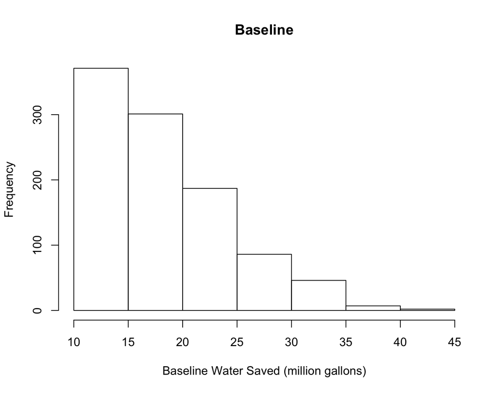

```r
pop <- population()
hist(pop[,2], xlab="Baseline Water Saved (million gallons)",
     main="Baseline", cex=24)
```

##declare_potential_outcomes()

The next step is to declare the full schedule of potential outcomes $Y(1)$ and $Y(0)$ under an assumption about the effect size of interest. We estimate that the customers in the higher incentive group save 1 million gallons more.

```r
# treatment effect of higher incentive
te = 1 # million gallons

potential_outcomes <-
  declare_potential_outcomes(
    Y_D_0=water_saved * u,
    Y_D_1=water_saved * u + te)
```

##Potential outcomes descriptives

```r
po <- potential_outcomes(pop)
kable(po[1:5,], digits=1)
```

| customers | water_saved | u | Y_D_0 | Y_D_1 |
| --- | --- | --- | --- | --- |
| 0001 | 16.6 | 1.1 | 17.9 | 18.9 |
| 0002 | 13.8 | 1.1 | 15.0 | 16.0 |
| 0003 | 18.4 | 1.1 | 19.6 | 20.6 |
| 0004 | 19.3 | 0.9 | 17.3 | 18.3 |
| 0005 | 26.6 | 1.1 | 28.6 | 29.6 |

##declare_sampling()

We are using a sample size of 150 customers.

```r
sampling <- declare_sampling(n=150)
sam <- sampling(po)
kable(sam[1:5,c(1:2,4:6)], row.names = FALSE,
      digits = 1)
```

| customers | water_saved | Y_D_0 | Y_D_1 | S_inclusion_prob |
| --- | --- | --- | --- | --- |
| 0012 | 25.8 | 31.5 | 32.5 | 0.2 |
| 0023 | 14.0 | 12.9 | 13.9 | 0.2 |
| 0025 | 24.4 | 25.4 | 26.4 | 0.2 |
| 0030 | 18.3 | 20.8 | 21.8 | 0.2 |
| 0045 | 18.0 | 19.1 | 20.1 | 0.2 |

##declare_assignment()

We randomly assignm 1/2 of sampled customers to the treatment.

```r
assigning <- declare_assignment(m = nrow(sam)/2,
                  assignment_variable="D")
assigned <- assigning(sam)
kable(assigned[1:5,c(1:2,4:5,7:8)],
      digits = 1)
```

| customers | water_saved | Y_D_0 | Y_D_1 | D | D_cond_prob |
| --- | --- | --- | --- | --- | --- |
| 0012 | 25.8 | 31.5 | 32.5 | 0 | 0.5 |
| 0023 | 14.0 | 12.9 | 13.9 | 1 | 0.5 |
| 0025 | 24.4 | 25.4 | 26.4 | 0 | 0.5 |
| 0030 | 18.3 | 20.8 | 21.8 | 1 | 0.5 |
| 0045 | 18.0 | 19.1 | 20.1 | 1 | 0.5 |

## Assessing balance

Review the balance in baseline water saved characteristics since random assignment has occured.

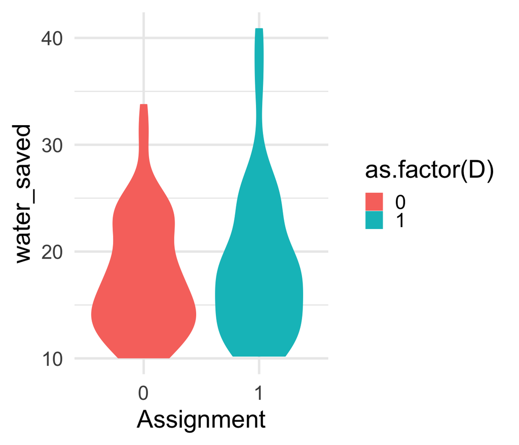

##declare_reveal()

This step declares how the potential outcomes are revealed by the random assignment

```r
revealing <- declare_reveal(assignment_variables=D)
```

##declare_estimand()

At this stage, we specify our target *estimand*, which is the quantity that we are trying to recover when estimating impact. Recall that we set this value to **1**

```r
estimand <- declare_estimand(ATE = te)
estimand(po)
```

```
##   inquiry_label estimand
## 1           ATE        1
```

##declare_estimator()

Next, we declare the estimators we use for recovering the estimand. While there are many advanced estimators, we’ll focus on the two core experimental estimators: 1. difference-in-means 2. difference-in-differences

```r
dim <- declare_estimator(Y ~ D, estimand = estimand,
          model =  difference_in_means, label = "DIM") #PH: Difference-in-means (Mean of treatment group - mean of control group)

did <- declare_estimator(Y - water_saved ~ D,
                         estimand = estimand,
          model =  difference_in_means, label = "DID") #PH: Difference-in-differences ([Mean of treatment group @ endline - Mean of treatment group @ baseline] - [Mean of control group @ endline - mean of control group @ baseline])
```

##declare_design()

This function brings all of the parts of the process together in a single design and allows for each part of the design to be simulated repeatedly.

```r
design <- population + potential_outcomes + sampling +
          assigning + revealing + estimand + dim + did
```

##diagnose_design()

At this stage, we can calculate various features of the design that we have specified

| design_label | estimator_label | bias | power | coverage |
| --- | --- | --- | --- | --- |
| design | DID | -0.0067887 | 0.830 | 0.948 |
| design | DIM | -0.0448559 | 0.118 | 0.948 |

## Looking under the hood, DIM

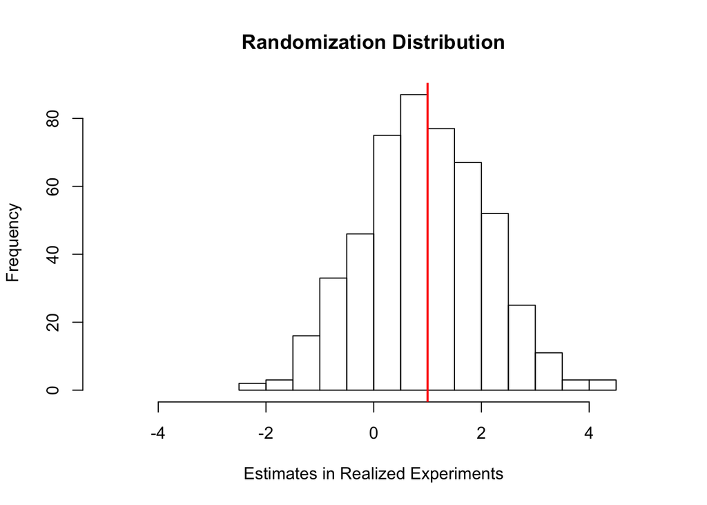

## Looking under the hood, DID

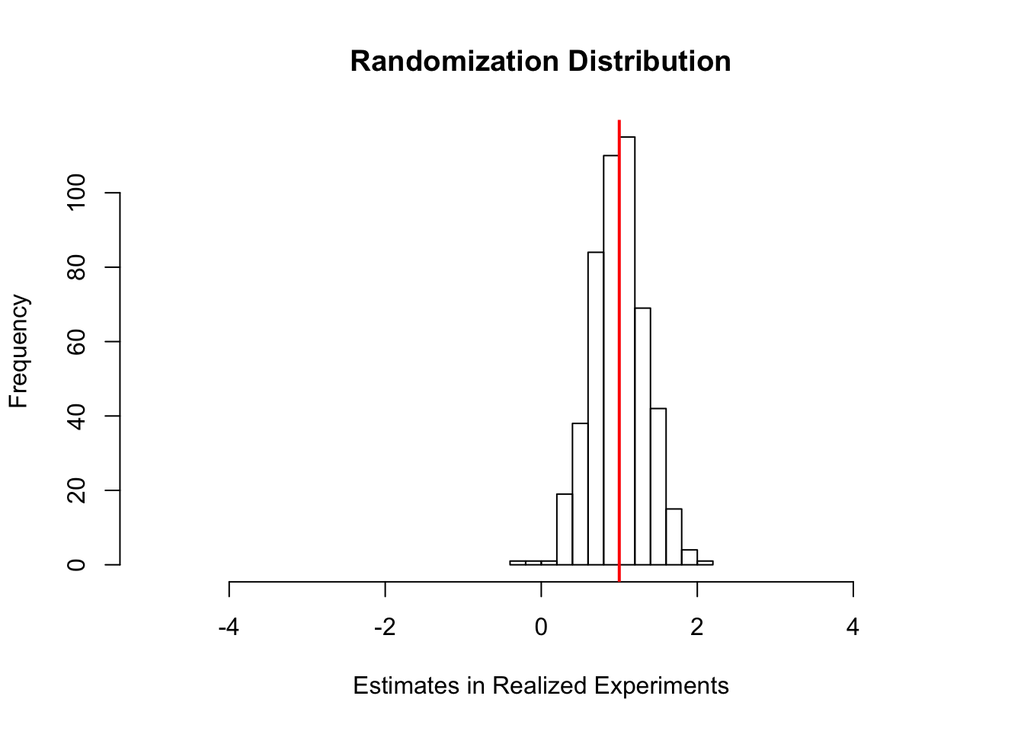